# STA 380, Part 2: Exercises 1

Kemei Zhuo

August 2, 2018

# Part A.

Visitors to your website are asked to answer a single survey question before they get access to the content on the page. Among all of the users, there are two categories: Random Clicker (RC), and Truthful Clicker (TC). There are two possible answers to the survey: yes and no. Random clickers would click either one with equal probability. You are also giving the information that the expected fraction of random clickers is 0.3. After a trial period, you get the following survey results: 65% said Yes and 35% said No. What fraction of people who are truthful clickers answered yes?

```r
rc_yes = 0.5
rc_no = 0.5
rc_weight = 0.3
tc_weight = 1 - rc_weight
tc_yes = (0.65 - rc_weight*rc_yes) / tc_weight
tc_yes
```

```
## [1] 0.7142857
```

# Part B.

Imagine a medical test for a disease with the following two attributes:

The sensitivity is about 0.993. That is, if someone has the disease, there is a probability of 0.993 that they will test positive.

The specificity is about 0.9999. This means that if someone doesn’t have the disease, there is probability of 0.9999 that they will test negative.

In the general population, incidence of the disease is reasonably rare: about 0.0025% of all people have it (or 0.000025 as a decimal probability).

Suppose someone tests positive. What is the probability that they have the disease? In light of this calculation, do you envision any problems in implementing a universal testing policy for the disease?

The people with no disease have a very high weight. Even though that the specificity is high, the high probabitliy of people with no disease still makes it a large number compared to the True positive rate times the probability of having the disease. Thus, it is hard to test the effectiveness of medical test.

```r
True_positive = 0.993
True_negative = 0.9999
False_positive = 1 - True_negative
Disease_proba = 0.000025
Positive_percentage = True_positive * Disease_proba + False_positive * (1-Disease_proba)
True_positive * Disease_proba / Positive_percentage
```

```
## [1] 0.1988824
```

# Exploratory analysis: green buildings

An Austin real-estate developer is interested in building a new 15-story mixed-use building on East Cesar Chaves, just across I-35 from downtown. The baseline construction costs are $100 million, with a 5% expected premium for green certification. She wants to know that whether it would be enocomicly worth to invest in a green building rather than an ordinary building.

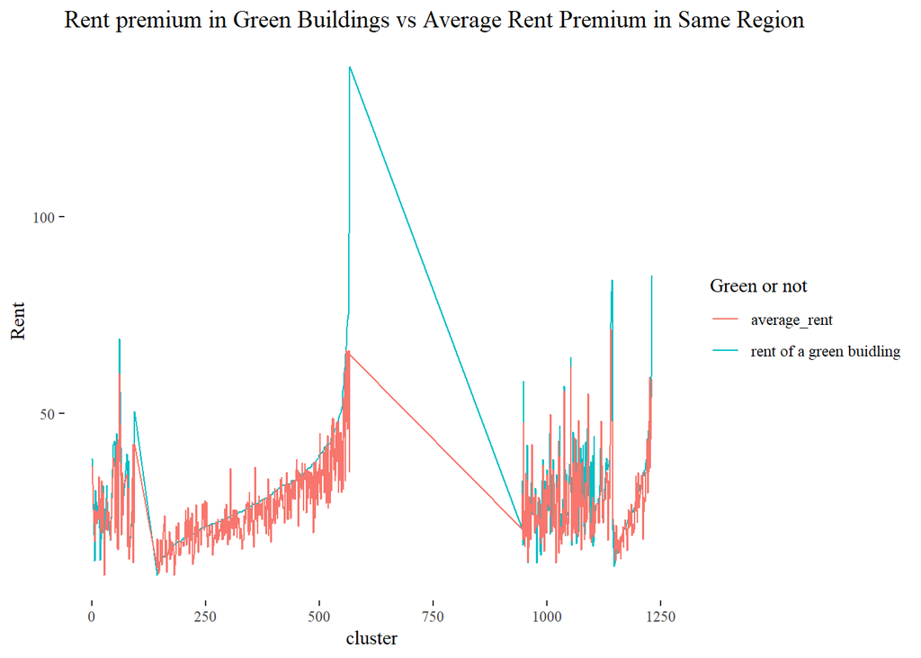

We know that a green building is associated with social responsibility and ecological awareness, and might therefore command a premium from potential tenants. We can see this relationship through the plot above: rent rate of green buidlings are higher than average price of the same region most of the time.

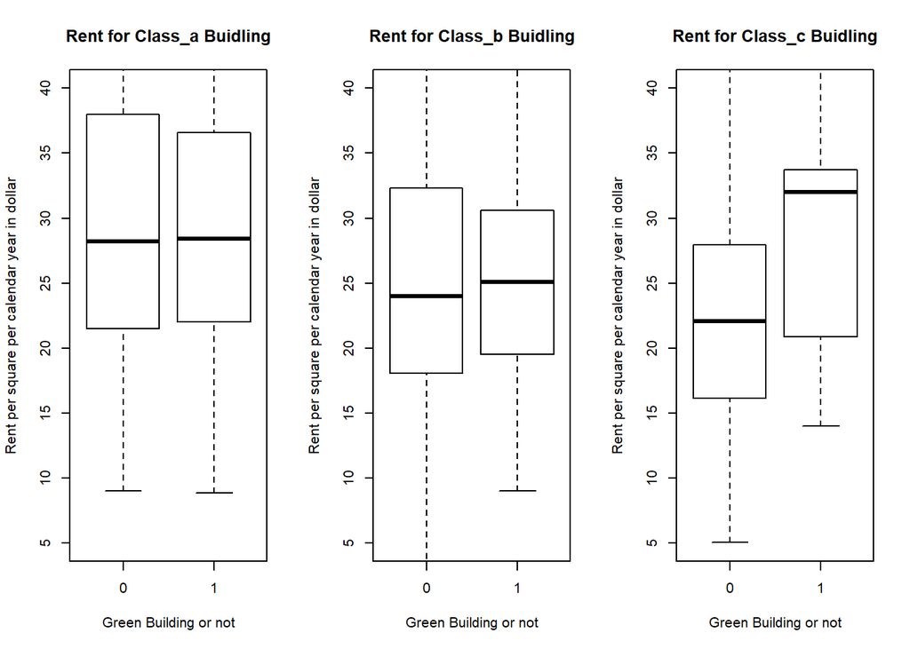

By looking at the rent under three classes of buildings: class a, class b, and class c, the rent premium decreases as the class of building decreases. It is surprising that a class c green building has the highest rate. However, a high rent premium is usually associated with low occupancy rate. Thus, we take both rent and leasing rate into consideration.

```r
data['rent_income_per_square'] = data['Rent'] * data['leasing_rate'] / 100
```

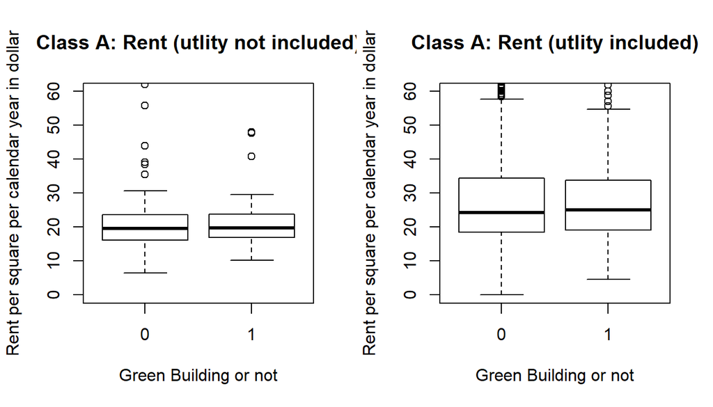

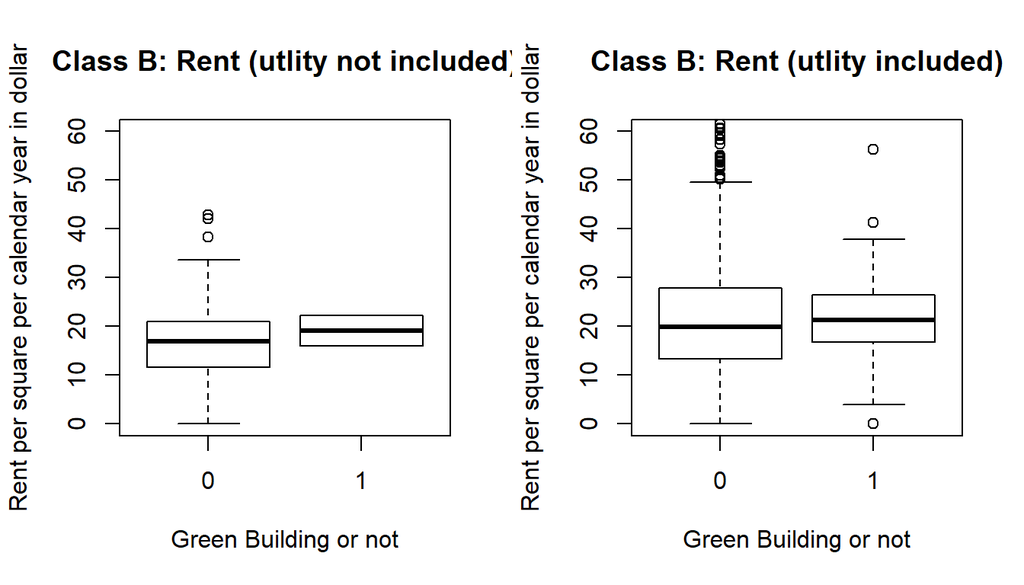

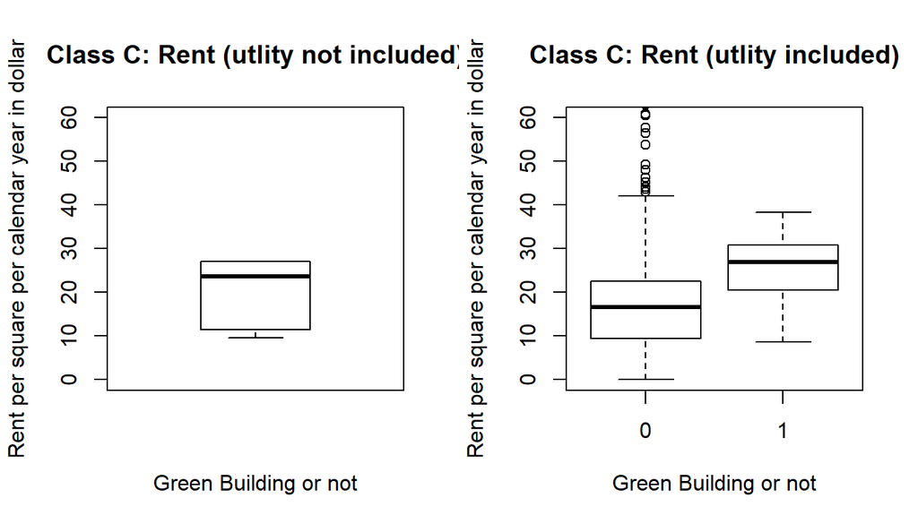

We don’t know which class our building will be classified into for sure, but we know that class of building is associated with building age. Assuming that the developer wants to build a good building and our building will be new, our building will be likely to be classified into class a.

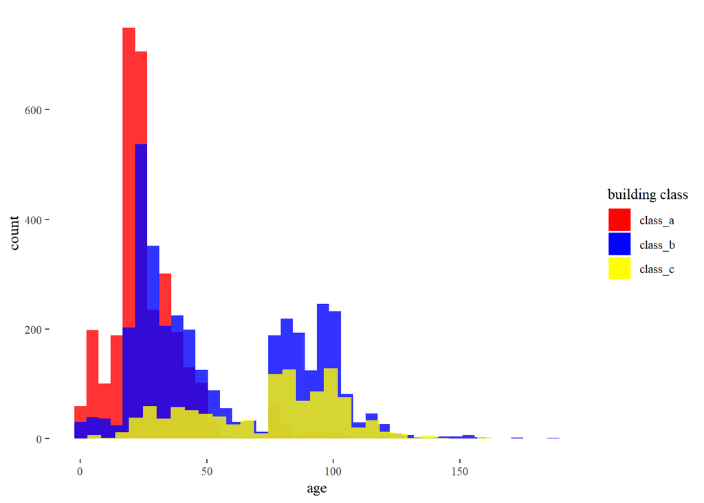

The majority of buildings include utility bill in rent premium, I use its medium as our base rent income per square. Because the building has 250,000 square feet, the total income from tenants per calendar year would be $4.9325\times 10^{6}$. If the developer decides to build an ordinary building, the total income from tenants per calendar year would be $4.87872\times 10^{6}$. The time to recover the total cost would be $21.2873796$ years for green building but $20.4971796$ years for non-green buidling if we don’t consider the interest rate or inflation rate. Thus, building an ordinary building saves 9 month to recover the cost. Because we used the rent income of non-net contract, a part our rent income is used to pay utility bills. A green building would have low utility costs so we pay less each year. There are other benefits assocaited with green buildings. Green buildings would have a longer buidling life with lower energy risk, and higher employee productivity. As you can see from the plot, a class c green building also have a high rent premium. Thus, by looking far into the future, the developer should biuld a green building.

# Bootstrapping

[output not shown]

[output not shown]

```
## [1] "SPY" "TLT" "LQD" "EEM" "VNQ"
```

```r
# the standard deviation
c(sd1, sd2, sd3, sd4, sd5)
```

```
## [1] 0.012450525 0.009157254 0.005220425 0.040247536 0.021163391
```

| portfolio | 5% VaR | Mean increase in wealth |
| --- | --- | --- |
| the even split | -5989.806 | 952.420 |
| safer split | -3051.928 | 670.199 |
| aggressive split | -11346.164 | 1258.458 |

# Market Segmentation

There are 9 clear market segments that appear to stand out in NutrientH20’s social-media audience. The characteristics of each group is summarized in the following table.

| name | more talked about | less mentioned |
| --- | --- | --- |
| first component | spam, adult, online_gaming | sports_fandom, food, parenting, religion |
| second component | chatter, photo_sharing, shopping, fasion | food, parenting, religion, sports_fandom |
| third component | health_nutrition, cooking, personal_fitness, beauty | travel, politics, news, computers, automotive |
| fourth component | college_uni, online_gaming, sports_playing, photo_sharing | health_nutrition, outdoors, politics, personal_fitness |
| fifth component | college_uni, online_gaming, sports_playing, tv_film | photo_sharing, shopping, beauty, chatter |
| sixth component | chatter, shopping, photo_sharing, eco | cooking, travel, fasion, beauty |
| seventh component | tv_film, art, crafts, small_businenss | college_uni, sports_playing, automotive, online_gaming |
| eighth component | travel, computer, dating, business | art, tv_film, news, automotive |
| nineth component | tv_film, business, music, health_nutrition | eco, small_business, spam, adult |

I first explored the vairable correlation using correlation plot. I circled out 9 clusters here because I used 9 cluster in my later PCA analysis.

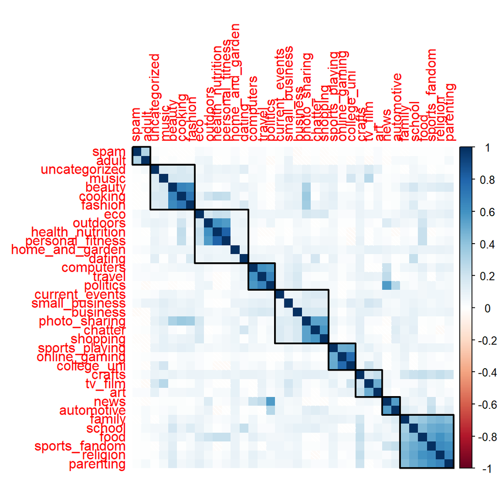

From PCA analysis, we see that photo_sharing, fashion, beauty, cooking, shopping, chatter are closely associated with each other at one end; school, family, food, parenting, sports_fandom, and dating are associated with each other at the opposite direction. The crafts and the politics are at the middle. I choocse 9 compontents, which would explain 57.595% of variance.

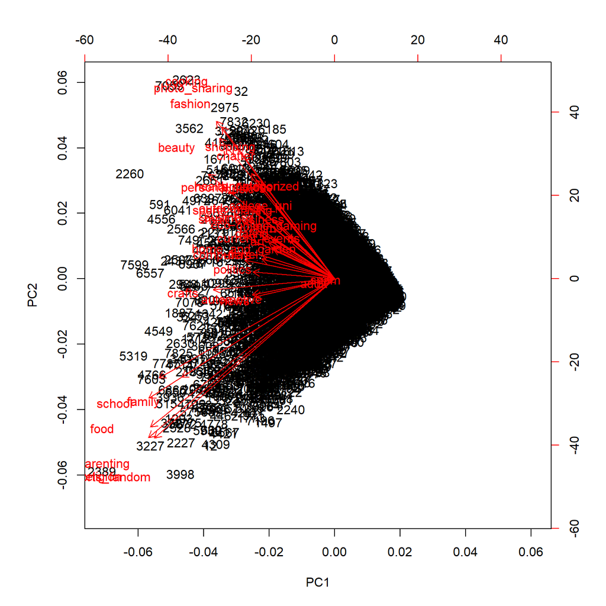

Then I sumamrized the cluster characteristics based on the the following model summary

```r
summary(pc1)
```

```
## Importance of components%s:
##                           PC1     PC2     PC3     PC4     PC5     PC6
## Standard deviation     2.1186 1.69824 1.59388 1.53457 1.48027 1.36885
## Proportion of Variance 0.1247 0.08011 0.07057 0.06541 0.06087 0.05205
## Cumulative Proportion  0.1247 0.20479 0.27536 0.34077 0.40164 0.45369
##                            PC7     PC8     PC9    PC10    PC11    PC12
## Standard deviation     1.28577 1.19277 1.15127 1.06930 1.00566 0.96785
## Proportion of Variance 0.04592 0.03952 0.03682 0.03176 0.02809 0.02602
## Cumulative Proportion  0.49961 0.53913 0.57595 0.60771 0.63580 0.66182
##                           PC13    PC14    PC15    PC16   PC17    PC18
## Standard deviation     0.96131 0.94405 0.93297 0.91698 0.9020 0.85869
## Proportion of Variance 0.02567 0.02476 0.02418 0.02336 0.0226 0.02048
## Cumulative Proportion  0.68749 0.71225 0.73643 0.75979 0.7824 0.80287
##                           PC19    PC20    PC21    PC22    PC23    PC24
## Standard deviation     0.83466 0.80544 0.75311 0.69632 0.68558 0.65317
## Proportion of Variance 0.01935 0.01802 0.01575 0.01347 0.01306 0.01185
## Cumulative Proportion  0.82222 0.84024 0.85599 0.86946 0.88252 0.89437
##                           PC25    PC26    PC27    PC28    PC29    PC30
## Standard deviation     0.64881 0.63756 0.63626 0.61513 0.60167 0.59424
## Proportion of Variance 0.01169 0.01129 0.01125 0.01051 0.01006 0.00981
## Cumulative Proportion  0.90606 0.91735 0.92860 0.93911 0.94917 0.95898
##                           PC31   PC32    PC33    PC34    PC35    PC36
## Standard deviation     0.58683 0.5498 0.48442 0.47576 0.43757 0.42165
## Proportion of Variance 0.00957 0.0084 0.00652 0.00629 0.00532 0.00494
## Cumulative Proportion  0.96854 0.9769 0.98346 0.98974 0.99506 1.00000
```